# Antconc 4.2.4

Author

Teodor Petrič

Published

April 26, 2024

```r
library(tidyverse)
library(tidytext)
library(tidylo)
library(ggthemes)
library(readtext)
library(quanteda)
library(quanteda.textstats)
library(quanteda.textplots)
library(wordcloud2)
source("wordcloud2a.R")
library(plotly)
library(htmlwidgets)
library(DT)
```

Begriffserklärungen von `OpenAI GPT4`.  
Die Datei mit den Beschreibungen habe ich mit `R` in `RStudio` zusammengestellt.

## 1 Korpusbildung

Ein temporäres Korpus kann mit *Ctrl+N* (*Open Files as Quick Corpus*) eröffnen. Im Beispiel verwenden wir jedoch den *Corpus Manager* (s. File Menu), da wir im Abschnitt zur Schlüsselwortanalyse zwei Koropora miteinander vergleichen wollen.

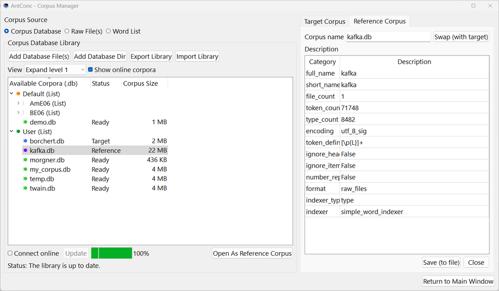

```r
bild = "data/Antconc/Antconc_Corpus_Manager.png"
knitr::include_graphics(bild)
```

## 2 Settings

In den Einstellungen (Settings) können wir Listen hinzufügen, beispielsweise eine Stoppwortliste für die deutsche Sprache. Mit dieser können wir Wörter herausfiltern, die die Inhaltsanalyse stören.

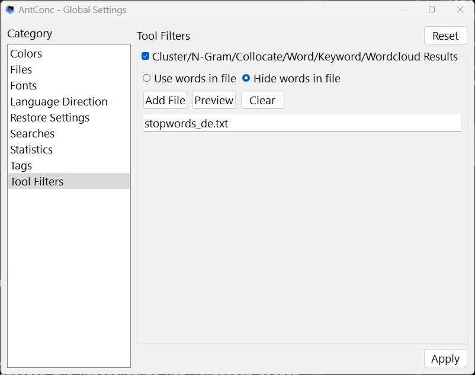

```r
bild = "data/Antconc/Antconc_tool_filters_stopwords.png"
knitr::include_graphics(bild)
```

*Stoppwortlisten* findet man im Internet für verschiedene Sprachen (z.B. in `Github` Repositorien). Die im Beispiel verwendete Stoppwortliste habe ich aus dem web-basierten Programm `Voyant Tools` herauskopiert und als Textdatei *stopwords_de.txt* gespeichert.

Es können auch andere Listen importiert werden (z.B. Lemmalisten, Pos-Tags u.a.), wobei das Format ensprechend angepasst werden muss.

Bei den einzelnen unten folgenden Analysemöglichkeiten gibt es neben grundlegenden Optionen auch fortgeschrittene Suchmöglichkeiten (*Advanced*), die jedoch in dieser Beschreibung nicht erläutert werden.

## 3 Wortliste

Nach der Entfernung von Stoppwörtern können wir verschiedene Evidenzen erstellen und Analysen durchführen, z.B. eine Liste mit den am häufigsten vorkommenden Wörtern im Ziel - oder Referenzkorpus. Als Zielkorpus haben wir Borcherts Kurzgeschichten definiert, als Referenzkorpus hingegen den Roman Der Prozess von Franz Kafka.

```r
bk_keyness <- read.table("data/Antconc/Word_results_borchert_prozess.txt", sep = "\t", dec = ".", header = TRUE)

bk_keyness |> DT::datatable()
```

|  | Type | POS | Headword | Rank | Freq | Range | NormFreq | NormRange |
| --- | --- | --- | --- | --- | --- | --- | --- | --- |
| 1 | beckmann |  |  | 10 | 396 | 1 | 11292.024 | 0.071 |
| 2 | oberst |  |  | 45 | 128 | 1 | 3649.947 | 0.071 |
| 3 | herr |  |  | 55 | 101 | 5 | 2880.036 | 0.357 |
| 4 | gott |  |  | 65 | 90 | 3 | 2566.369 | 0.214 |
| 5 | leben |  |  | 67 | 87 | 7 | 2480.824 | 0.5 |
| 6 | tür |  |  | 69 | 82 | 7 | 2338.247 | 0.5 |
| 7 | gut |  |  | 87 | 62 | 8 | 1767.943 | 0.571 |
| 8 | mädchen |  |  | 87 | 62 | 6 | 1767.943 | 0.429 |
| 9 | sah |  |  | 93 | 57 | 11 | 1625.367 | 0.786 |
| 10 | direktor |  |  | 98 | 54 | 1 | 1539.821 | 0.071 |

Die Tabelle zeigt:  
- die Rangfolge einer Wortform (Rank),  
- ihre Tokenfrequenz (Gebrauchshäufigkeit, Freq),  
- in wie vielen Texten eine Wortform vorkommt (Range),  
- die normalisierte Frequenz (Tokenfrequenz pro Million Wörter: z.B. *beckmann* hat 396*10^6/35069 = 11292, wobei N = 35069 Tokens in 14 Kurgeschichten),  
- und den prozentualen Anteil von Texten mit einer bestimmten Wortform (NormRange).

## 4 Konkordanz (KWIC)

Eine *Konkordanz* (Keywords in Context) ist einer Liste von Kontexten, in den das von uns gesuchte Wort auftritt. Im Beispiel geben wir die Wortform *tür* ein, die laut Wortliste in 7 (Range) von 14 Kurzgeschichten vorkommt, und zwar insgesamt 82-mal.

Der Wortstamm *Tür* kommt in Borcherts Kurzgeschichten noch häufiger vor. Um diese Kontextstellen zu ermitteln, können wir *reguläre Ausdrücke* (Regex - regular expressions) nutzen, z.B. `\b(^[A-Z]\w+)?[Tt]ür(en)?\b`.

`\b` Wortgrenze (border),  
`^[A-Z]` großer Anfangsbuchstabe,  
`\w+` ein oder mehrere Buchstaben oder Ziffern,  
`()?` alles in der Klammer is optional,  
`[Tt]` großes oder kleines “T”.

[figure not shown]

```r
bild = "data/Antconc/Antconc_kwic.png"
knitr::include_graphics(bild)
```

Die regulären Ausdrücke können vorher auf der Webseite [Regex101](https://regex101.com/) konstruiert, ausprobiert und dann in `Antconc` zur Suche eingesetzt werden (Anmerkung: in manchen Fällen gibt es Unterschiede zwischen Regex-Varianten oder besondere Einstellungen: z.B. muss man in `Antconc` *Case* setzen).

```r
kwic <- read.table("data/Antconc/KWIC_results_borchert_prozess.txt", sep = "\t", dec = ".", header = TRUE)

kwic |> DT::datatable()
```

|  | File | Left.Context | Hit | Right.Context |
| --- | --- | --- | --- | --- |
| 1 | borchert_draussen.txt | Leute hier auf der Welt – 2. Szene (Ein Zimmer. Abends. Eine | Tür | kreischt und schlägt zu. Beckmann. Das Mädchen.) Mädchen: So, |
| 2 | borchert_draussen.txt | dicht hinter dir. Mädchen (schreit auf und stürzt davon. Eine | Tür | kreischt und schlägt zu. Dann hört man ganz laut |
| 3 | borchert_draussen.txt | Ich will nicht mehr Beckmann sein! (Er läuft hinaus. Eine | Tür | kreischt und schlägt zu. Dann hört man den Wind |
| 4 | borchert_draussen.txt | fluchte – fluchte Pflicht! Komm! Komm! 3. Szene (Eine Stube. Abend. Eine | Tür | kreischt und schlägt zu. Der Oberst und seine Familie. |
| 5 | borchert_draussen.txt | das essen. Mutter: Ja, aber – aber das trockene Brot? (Eine | Tür | kreischt und schlägt zu) Beckmann (wieder auf der Straße. |
| 6 | borchert_draussen.txt | das sind so die Tatsachen – – (Beckmann geht grußlos ab. Eine | Tür | kreischt und schlägt zu.) Direktor: Aber junger Mann! Warum |
| 7 | borchert_draussen.txt | kommt nach Hause, und da ist sein Bett besetzt. Eine | Tür | schlägt zu, und er steht draußen. Ein Mann kommt |
| 8 | borchert_draussen.txt | stöhnt andauernd einen Namen. Und der Name heißt Beckmann. Eine | Tür | schlägt zu, und er steht draußen. Ein Mann kommt |
| 9 | borchert_draussen.txt | Er sucht Arbeit, aber ein Direktor ist feige, und die | Tür | schlägt zu, und wieder steht er draußen. Ein Mann |
| 10 | borchert_draussen.txt | aber eine alte Frau trauert um das Gas, und die | Tür | schlägt zu, und er steht draußen. Ein Mann kommt |

[output cut: 90 more lines]

## 5 Dispersion

### 5.1 Visualisierung

Die *Plot*-Option ermöglicht eine visuelle Darstellung der gefundenen Textstellen. Im Beispiel sehen wir, dass der Wortstamm *Tür* insbesondere in der Kurzgeschichte *Draußen vor der Tür* eine große Rolle spielt. Erkennbar ist die Verteilung, Streuung oder Konzentration dieses Wortstammes in der jeweiligen Geschichte.

[figure not shown]

```r
bild = "data/Antconc/Antconc_plot_borchert_prozess.png"
knitr::include_graphics(bild)
```

### 5.2 Berechnung der Dispersion

In der Korpuslinguistik bezieht sich der Dispersionswert darauf, wie gleichmäßig ein Wort über verschiedene Teile eines Korpus verteilt ist. Ein hoher Dispersionswert bedeutet, dass das Wort in vielen verschiedenen Texten oder Textabschnitten des Korpus häufig vorkommt, während ein niedriger Wert darauf hindeutet, dass das Wort in wenigen Texten konzentriert ist.

Es gibt mehrere Methoden zur Berechnung der Dispersion, aber eine gängige Methode ist die *Normalized Entropy Measure*. Diese Methode betrachtet die Verteilung der Frequenz eines Wortes über die verschiedenen Texte eines Korpus. Die Formel zur Berechnung der *Normalized Entropy Dispersion* ist:

$$D = - \sum_{i=1}^n \left( \frac{f_i}{f} \log_2 \frac{f_i}{f} \right) \times \frac{1}{\log_2 n}$$
wo: - $f_i$ die Häufigkeit des Wortes in einem Teil des Korpus (z.B. einem Text) ist, - $f$ die Gesamthäufigkeit des Wortes im gesamten Korpus ist, - $n$ die Anzahl der Teile ist, in die das Korpus unterteilt ist (z.B. die Anzahl der Texte), - $D$ der Dispersionswert ist.

### 5.3 Interpretation

- **Nähe zu 1**: Ein Wert nahe 1 bedeutet eine sehr gleichmäßige Verteilung des Wortes über alle Teile des Korpus. Das Wort ist somit in allen untersuchten Segmenten relativ gleich verteilt.
- **Nähe zu 0**: Ein Wert nahe 0 bedeutet, dass das Wort sehr ungleichmäßig verteilt ist, was darauf hindeutet, dass es möglicherweise in nur einem oder sehr wenigen Texten konzentriert auftritt.

Die Dispersionswerte in der Beispielstabelle variieren von 0.683 bis 0.000. Die Dispersionswerte für die Wörter mit dem Stamm *Tür* in den Kurzgeschichten von Borchert geben Aufschluss darüber, wie gleichmäßig der Wortstamm über die analysierten Texte verteilt ist. Sie helfen uns zu verstehen, in welchem Maß das Wort bzw. der Wortstamm in verschiedenen Kontexten innerhalb des Gesamtkorpus verwendet wird. Hier ist, wie Sie die spezifischen Werte interpretieren können:

1. **Hohe Dispersionswerte (z.B., 0.683)**: Dieser Wert zeigt an, dass das Wörter mit dem Wortstamm “Tür” recht gleichmäßig verteilt sind. Das deutet darauf hin, dass es ein häufiges und thematisch relevantes Wort in dieser Geschichte ist.
2. **Mittlere Dispersionswerte (z.B., 0.592, 0.333, 0.274)**: Diese Werte weisen darauf hin, dass “Tür” in diesen Texten präsent ist. Wörter mit diesem Wortstamm könnten nur in bestimmten Kontexten dieser Geschichten wichtiger sein, was sich in seiner ungleichmäßigen Verteilung widerspiegelt.
3. **Niedrige Dispersionswerte (z.B., 0.000)**: Ein Dispersionswert von 0.000 bedeutet, dass “Tür” in den betreffenden Geschichten (fast) überhaupt nicht vorkommt. Dies deutet darauf hin, dass es in diesen spezifischen Texten entweder thematisch irrelevant ist oder (eventuell) durch Synonyme ersetzt wird.

### 5.4 Zusammenfassend

Die Dispersionswerte zeigen, dass das Wort “Tür” in einigen Geschichten von Borchert eine signifikante Rolle spielt und möglicherweise eine wichtige thematische oder symbolische Bedeutung hat, während seine Abwesenheit in anderen Geschichten darauf hinweisen könnte, dass andere Themen oder Elemente dort vorherrschen.

Diese Analyse der Dispersionswerte kann nützlich sein, um die thematische Konsistenz oder Vielfalt in Borcherts Werk zu untersuchen, sowie um zu verstehen, wie bestimmte Begriffe über ein literarisches Korpus verteilt sind.

```r
dispers <- read.table("data/Antconc/Antconc_Plot_results_borchert_prozess.txt", sep = "\t", dec = ".", header = TRUE)

dispers |> DT::datatable()
```

|  | Row | FileID | FilePath | FileTokens | Freq | NormFreq | Dispersion | Plot |
| --- | --- | --- | --- | --- | --- | --- | --- | --- |
| 1 | 1 | 2 | borchert_draussen.txt | 18944 | 79 | 4170.186 | 0.683 |  |
| 2 | 2 | 5 | borchert_holz.txt | 1191 | 4 | 3358.522 | 0.592 |  |
| 3 | 3 | 1 | borchert_bruder.txt | 1015 | 2 | 1970.443 | 0.333 |  |
| 4 | 4 | 7 | borchert_kirschen.txt | 558 | 2 | 3584.229 | 0.333 |  |
| 5 | 5 | 6 | borchert_hundeblume.txt | 4754 | 13 | 2734.539 | 0.274 |  |
| 6 | 6 | 8 | borchert_kraehen.txt | 1359 | 1 | 735.835 | 0 |  |
| 7 | 7 | 9 | borchert_kuechenuhr.txt | 933 | 1 | 1071.811 | 0 |  |

## 6 File View

Durch Anklicken von Wörtern in den verschiedenen Ergebnistabellen ist es auch möglich, sich diese Textstellen genauer anzusehen. Das gesuchte Wort erscheint in blauer Farbe.

## 7 Cluster

Cluster sind Häufungen oder Verbindungen von Wörtern. Im Beispiel sind Wörter mit dem Stamm *Tür* zu sehen (Mindestfrequenz: 2).

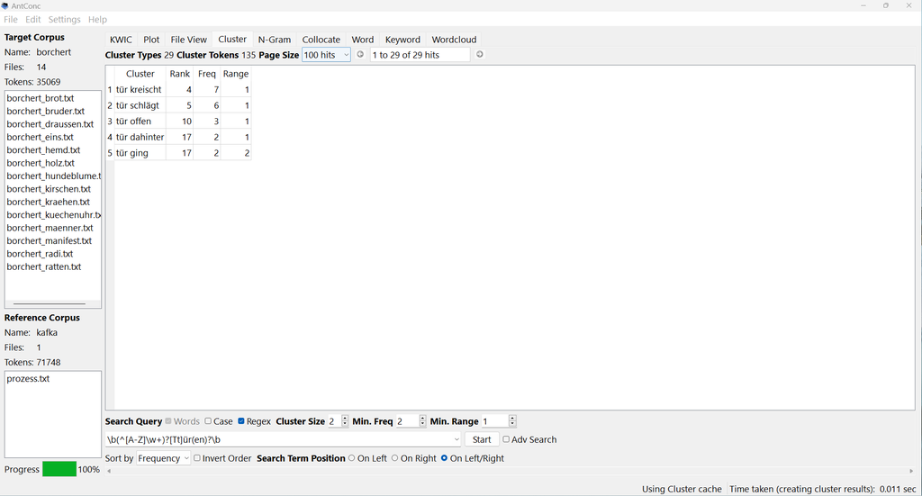

```r
bild = "data/Antconc/Antconc_cluster.png"
knitr::include_graphics(bild)
```

Es gibt mehrere Einstellungsmöglichkeiten, und zwar (außer anderswo erläuterten: Range, Min.Freq, Case, Regex, …):  
- die Positionswahl (Partnerwort erscheint vor dem gesuchten Wort (on left), danach (on right) oder kann sowohl links als auch rechts vom gesuchten Wort erscheinen (on left/right);  
- Cluster Size (wie viele Wörter oder Glieder).

Im Beispiel suchen wir nach zweigliedrigen, zumindest zweimal im Borchert-Korpus vorkommenden Verbindungen mit Wörtern, die den Stamm *Tür* enthalten und diesem voran- oder nachgestellt sind. Für die Suche verwenden wir im Beispiel einen regulären Ausdruck und schalten die Unterscheidung von Groß und Kleinbuchstaben aus.

```r
cluster <- read.table("data/Antconc/Cluster_results_borchert_prozess.txt", sep = "\t", dec = ".", header = TRUE)

cluster |> DT::datatable()
```

|  | Cluster | Rank | Freq | Range | NormFreq | NormRange |
| --- | --- | --- | --- | --- | --- | --- |
| 1 | tür kreischt | 4 | 7 | 1 | 0.052 | 0.071 |
| 2 | tür schlägt | 5 | 6 | 1 | 0.044 | 0.071 |
| 3 | tür offen | 10 | 3 | 1 | 0.022 | 0.071 |
| 4 | tür dahinter | 17 | 2 | 1 | 0.015 | 0.071 |
| 5 | tür ging | 17 | 2 | 2 | 0.015 | 0.143 |

### 7.1 Interpretation der Werte

Die vorgestellten Cluster wie „tür kreischt“, „tür schlägt“, und „tür offen“ könnten kontextuelle Verwendungen des Wortes “Tür” in Borcherts Werken reflektieren, die möglicherweise spezifische narrative oder thematische Bedeutungen tragen. Die Frequenzwerte geben an, wie oft solche Kombinationen vorkommen, was auf ihre Bedeutung oder Prominenz im Text hinweisen könnte. Die Tatsache, dass die meisten Cluster nur in einem Textbereich (Range = 1) gefunden werden, könnte darauf hindeuten, dass diese spezifischen Phrasen auf bestimmte Geschichten oder Kontexte beschränkt sind.

Diese Informationen können besonders nützlich sein, um zu verstehen, wie Borchert das Motiv der Tür in verschiedenen Erzählkontexten nutzt, und um Muster in seinem Schreibstil oder thematischen Fokussen zu identifizieren.

## 8 Ngram

Eine ähnliche Suchmöglichkeit ist die Ngram-Analyse. Meist werden die Häufigkeit von zwei (oder mehreren) nacheinader auftretenden Wörtern ermittelt. Antconc erlaubt jedoch auch die Ermittlung von nicht-zusammenhängen (diskontinuierlichen) Ngramen (Open-Slot). Im Beispiel suchen wir mit einem regulären Ausdruck zweigliedrige Ngrame, die durch irgend ein Wort unterbrochen werden.

[figure not shown]

```r
bild = "data/Antconc/Antconc_ngram.png"
knitr::include_graphics(bild)
```

Die Einstellung dafür in unserem Beispiel ist: Ngram size = 3, Open Slot = 1, Mindestfrequenz = 2.

```r
ngram <- read.table("data/Antconc/N-Gram_results.txt", sep = "\t", dec = ".", header = TRUE)

ngram |> DT::datatable()
```

|  | Type | Rank | Freq | Range | NormFreq | NormRange | S1_TT | S1_Ent |
| --- | --- | --- | --- | --- | --- | --- | --- | --- |
| 1 | tür + beckmann | 6 | 2 | 1 | 57.076 | 0.071 | 1 | 1 |
| 2 | tür + offen | 6 | 2 | 1 | 57.076 | 0.071 | 1 | 1 |
| 3 | haustüren + beispiel | 14 | 1 | 1 | 28.538 | 0.071 | 1 | 0 |
| 4 | küchentür + kratzt | 14 | 1 | 1 | 28.538 | 0.071 | 1 | 0 |
| 5 | schlafzimmertür + zugemacht | 14 | 1 | 1 | 28.538 | 0.071 | 1 | 0 |
| 6 | tür + abzuschließen | 14 | 1 | 1 | 28.538 | 0.071 | 1 | 0 |
| 7 | tür + aufriß | 14 | 1 | 1 | 28.538 | 0.071 | 1 | 0 |
| 8 | tür + bewegte | 14 | 1 | 1 | 28.538 | 0.071 | 1 | 0 |
| 9 | tür + davongejagt | 14 | 1 | 1 | 28.538 | 0.071 | 1 | 0 |
| 10 | tür + deutschland | 14 | 1 | 1 | 28.538 | 0.071 | 1 | 0 |

[output cut: 15 more lines]

In der Ngram-Tabelle beziehen sich die Spalten „S1_TT“ und „S1_Ent“ auf spezifische metrische Werte für die analysierten Ngram-Kombinationen:

1. **S1_TT**: Dies steht für „Test Type Statistic“, was ein statistischer Wert ist, der typischerweise die Signifikanz der Assoziation zwischen den Worten im Ngram ausdrückt. Ein Wert von 1.0 in dieser Spalte könnte darauf hinweisen, dass das Ngram als signifikant relevant betrachtet wird, basierend auf dem verwendeten statistischen Test. Es kann auch bedeuten, dass die Frequenz des Ngrams im untersuchten Korpus genau entspricht, was auf Basis der Einzelwörter erwartet wird.
2. **S1_Ent**: Dies steht für „Entropy“, was ein Maß für die Informationsdichte oder -verteilung in den Daten ist. Entropie in diesem Kontext kann anzeigen, wie vorhersehbar oder gleichmäßig die Verteilung eines Ngrams über das Korpus ist. Ein Wert von 1.0 zeigt eine höhere Gleichmäßigkeit oder Vorhersehbarkeit in der Verteilung an, während ein Wert von 0.0 darauf hindeutet, dass die Verteilung des Ngrams sehr ungleichmäßig oder konzentriert ist (typischerweise auf sehr wenige Vorkommnisse oder Kontexte beschränkt).

Diese Werte helfen dabei, die linguistische Relevanz und die Verteilungscharakteristika der Ngrams im Korpus zu bewerten. In Ihrer Tabelle zeigen die meisten Einträge einen Testtypen-Wert von 1.0, was bedeutet, dass diese Ngrams statistisch signifikante Kombinationen sind, und variierende Entropie-Werte, die die Verteilungsunterschiede dieser Kombinationen im Korpus widerspiegeln.

In der Ngram-Tabelle, die die Spalten „S1_TT“ (Test Type Statistic) und „S1_Ent“ (Entropy) enthält, repräsentieren diese beiden Werte verschiedene statistische Eigenschaften der Ngram-Kombinationen. Hier ist eine detaillierte Erklärung darüber, wie diese Metriken typischerweise berechnet werden könnten, obwohl die genauen Formeln je nach spezifischer Implementierung in AntConc variieren können:

### 8.1 S1_TT (Test Type Statistic)

Diese Metrik misst typischerweise die statistische Signifikanz der Assoziation zwischen den Komponenten eines Ngrams. Ein häufig verwendetes Maß für diese Statistik ist der **t-Wert**, der in der Korpuslinguistik oft verwendet wird, um die Stärke der Assoziation zwischen Wörtern zu beurteilen. Die allgemeine Formel für den t-Wert ist:

$$t = \frac{(O - E)}{\sqrt{V}}$$

wo: - $O$ die beobachtete Frequenz des Ngrams im Korpus ist. - $E$ die erwartete Frequenz des Ngrams ist, berechnet unter der Annahme, dass die Vorkommen der einzelnen Wörter unabhängig voneinander sind. - $V$ die Varianz der beobachteten Frequenz ist.

### 8.2 S1_Ent (Entropy)

Entropy (Entropie) misst die Gleichmäßigkeit der Verteilung eines Ngrams über verschiedene Teile des Korpus. Eine hohe Entropie deutet darauf hin, dass das Ngram gleichmäßig über den gesamten Korpus verteilt ist, während eine niedrige Entropie anzeigt, dass das Ngram in bestimmten Teilen des Korpus konzentriert ist. Die Entropie wird typischerweise wie folgt berechnet:

$$H = - \sum p(x) \log_2 p(x)$$

wo:  
- $p(x)$ die Wahrscheinlichkeit des Auftretens des Ngrams in einem bestimmten Teil des Korpus ist.  
- Die Summierung erfolgt über alle Teile des Korpus.

Die Entropie wird oft in Bits gemessen, und die Basis 2 des Logarithmus wird verwendet, um die Berechnung in einer für Informationstheorie typischen Einheit durchzuführen.

Diese beiden Metriken zusammen geben Einblick in die Stärke und die Gleichmäßigkeit der Verteilung der Ngram-Kombinationen innerhalb des Korpus. Während S1_TT auf die Stärke der Assoziation fokussiert, gibt S1_Ent Aufschluss darüber, wie diese Assoziation über das Korpus verteilt ist.

## 9 Collocate

Antconc macht auch bestimmte Kollokationsanalysen möglich.

[figure not shown]

```r
bild = "data/Antconc/Antconc_Collocate_borschert_prozess.png"
knitr::include_graphics(bild)
```

Die Tabelle enthält Daten zu Kollokationen eines bestimmten Wortes (“Tür”). Jede Zeile zeigt eine unterschiedliche Kollokation und verschiedene statistische Maße, die die Beziehung dieser Kollokationen zum Fokuswort in Ihrem Korpus beschreiben. Hier sind die Erklärungen zu den Spalten:

1. **Collocate**: Das Kollokat, also das Wort, das in signifikantem Zusammenhang mit dem Fokuswort (hier vielleicht “Tür”) steht.
2. **Rank**: Die Rangposition des Kollokats basierend auf einem der statistischen Maße, wie z.B. Häufigkeit oder Likelihood.
3. **Freq(Scaled)**: Eine skalierte oder normalisierte Häufigkeit des Kollokats, die die tatsächliche Häufigkeit in Relation zur Größe des Korpus oder anderen Faktoren angibt.
4. **FreqLR**: Die Häufigkeit des Kollokats in unmittelbarer Nähe zum Fokuswort (links und rechts).
5. **FreqL**: Die Häufigkeit des Kollokats links vom Fokuswort.
6. **FreqR**: Die Häufigkeit des Kollokats rechts vom Fokuswort.
7. **Range**: Die Anzahl verschiedener Texte oder Segmente des Korpus, in denen das Kollokat in Verbindung mit dem Fokuswort auftritt.
8. **Likelihood**: Ein Wert für die statistische Signifikanz der Kollokation, gemessen durch den Likelihood-Ratio-Test, der aufzeigt, wie wahrscheinlich es ist, dass die beobachtete Kollokation nicht zufällig ist.
9. **Effect**: Die Effektgröße, die angibt, wie stark die Assoziation zwischen dem Fokuswort und dem Kollokat ist, gemessen als logaritmiertes Verhältnis der relativen Häufigkeiten.

### 9.1 Interpretation der Werte

- **Höhere Werte bei “Likelihood” und “Effect”**: Diese zeigen eine stärkere und statistisch signifikantere Assoziation zwischen den Kollokaten und dem Fokuswort. Zum Beispiel hat “kreischt” eine hohe Effektgröße, was darauf hindeutet, dass es stark mit dem Fokuswort assoziiert ist.
- **“Range”**: Wenn dieser Wert hoch ist, bedeutet es, dass das Kollokat in vielen verschiedenen Kontexten mit dem Fokuswort erscheint, was auf eine breite Anwendung oder Wichtigkeit im Korpus hinweist.

Die Daten in Ihrer Tabelle sind nützlich, um zu verstehen, wie und in welchen Kontexten bestimmte Wörter in Beziehung zueinander stehen, und können Aufschluss darüber geben, welche Themen oder Konzepte in Ihrem Korpus besonders relevant sind.

```r
collocate <- read.table("data/Antconc/Collocate_results.txt", sep = "\t", dec = ".", header = TRUE)

collocate |> DT::datatable()
```

|  | Collocate | Rank | Freq.Scaled. | FreqLR | FreqL | FreqR | Range | Likelihood | Effect |
| --- | --- | --- | --- | --- | --- | --- | --- | --- | --- |
| 1 | schlägt | 2 | 140 | 12 | 0 | 12 | 1 | 59.253 | 4.888 |
| 2 | offen | 5 | 80 | 8 | 1 | 7 | 1 | 41.984 | 5.111 |
| 3 | kreischt | 6 | 70 | 7 | 0 | 7 | 1 | 36.73 | 5.111 |
| 4 | tür | 8 | 820 | 13 | 6 | 7 | 1 | 23.215 | 2.454 |
| 5 | dahinter | 9 | 70 | 5 | 1 | 4 | 1 | 22.825 | 4.625 |
| 6 | tod | 11 | 440 | 9 | 5 | 4 | 1 | 19.941 | 2.821 |
| 7 | draußen | 12 | 350 | 8 | 6 | 2 | 2 | 19.28 | 2.981 |
| 8 | straßenfeger | 13 | 220 | 6 | 2 | 4 | 1 | 16.352 | 3.236 |
| 9 | zugemacht | 14 | 30 | 3 | 0 | 3 | 3 | 15.73 | 5.111 |

Die Berechnung von “Likelihood” und “Effect” in Kollokationsanalysen, wie sie in AntConc und anderen korpuslinguistischen Tools verwendet werden, basiert auf bestimmten statistischen Verfahren. Hier sind die allgemeinen Formeln und Erklärungen für diese beiden Maße:

### 9.2 Likelihood (Log-Likelihood)

Die “Likelihood” oder genauer der “Log-Likelihood” misst die Wahrscheinlichkeit, dass die beobachtete Häufigkeit einer Kollokation im Vergleich zur erwarteten Häufigkeit auftritt, wenn keine spezifische Beziehung zwischen den Wörtern bestehen würde. Die Berechnung basiert auf einer Kontingenztabelle, die die Frequenzen des Fokuswortes und des Kollokats sowohl gemeinsam als auch separat darstellt.

Die Formel für den Log-Likelihood-Test lautet:
$$G^2 = 2 \sum_{i=1}^{k} O_i \log \left(\frac{O_i}{E_i}\right)$$

wo:  
- $O_i$ die beobachteten Häufigkeiten der Zellen der Kontingenztabelle sind.  
- $E_i$ die erwarteten Häufigkeiten sind, basierend auf der Unabhängigkeitsannahme.  
- $k$ die Anzahl der Zellen in der Kontingenztabelle (typischerweise 4: Fokuswort und Kollokat gemeinsam, jedes einzeln, und keines von beiden).

### 9.3 Effect (Effektgröße)

Die “Effect” Größe (Effektgröße) in Kollokationsanalysen wird oft durch das Maß “Log Ratio” oder das logaritmierte Verhältnis der relativen Häufigkeiten berechnet. Diese Größe gibt an, wie stark die beobachtete Assoziation im Vergleich zur erwarteten ist, wenn die Wörter unabhängig voneinander wären.

Die Formel lautet:
$$\text{Effect Size} = \log_2 \left(\frac{P(w_1 \mid w_2)}{P(w_1)}\right)$$

wo:  
- $P(w_1 \mid w_2)$ die bedingte Wahrscheinlichkeit ist, dass Wort 1 auftritt, gegeben Wort 2 ist auch aufgetreten.  
- $P(w_1)$ die allgemeine Wahrscheinlichkeit (bzw. die Randhäufigkeit) ist, dass Wort 1 auftritt.  
- Der Logarithmus zur Basis 2 wird genutzt, damit die Effektgröße in Bit gemessen wird.

Diese Berechnungen helfen, die statistische Signifikanz und die Stärke der Assoziation zwischen zwei Wörtern in einem Korpus zu bestimmen, was für linguistische Studien von großer Bedeutung ist.

## 10 Keywords

Lawrence Anthony’s `AntConc` ist ein beliebtes Werkzeug für korpuslinguistische Analysen, das verschiedene statistische Methoden zur Untersuchung von Textdaten bietet. In Version 4.2.4 von AntConc werden für die Berechnung von **Schlüsselwörtern** (Keywords) zwei verschiedene Maße verwendet: *Likelihood Ratio* und *Effect Size*.

### 10.1 Keyness (Likelihood)

**Berechnungsformel:** Die Likelihood Ratio, auch als Log-Likelihood bekannt, wird häufig in der Korpuslinguistik verwendet, um zu bestimmen, ob das Vorkommen eines Wortes in einem Korpus im Vergleich zu einem Referenzkorpus signifikant ist. Die Formel ist:

$$G^2 = 2 \sum (O \log(\frac{O}{E}))$$

wo:  
- $O$ = Beobachtete Häufigkeit in jedem Feld der Kontingenztabelle (Korpus und Referenzkorpus).  
- $E$ = Erwartete Häufigkeit, basierend auf der Annahme, dass die Gesamtanzahl der Wörter gleich verteilt ist.

**Interpretation der Werte:** - Ein höherer Wert von $G^2$ deutet darauf hin, dass das Wort in einem Korpus im Vergleich zum anderen häufiger oder seltener ist, als es die Zufallsverteilung erwarten ließe. Ein hoher $G^2$-Wert zeigt eine hohe Signifikanz an, dass das Wort in einem der Korpora über- oder unterrepräsentiert ist.

### 10.2 Keyness (Effect Size)

**Berechnungsformel:** Die Effect Size (Effektgröße) in AntConc wird üblicherweise als logarithmiertes Verhältnis der relativen Häufigkeiten in zwei Korpora berechnet:

$$\text{Effect Size} = \log_2(\frac{f_1 / N_1}{f_2 / N_2})$$

wo:  
- $f_1$ und $f_2$ = Häufigkeiten des Wortes in den beiden Korpora.  
- $N_1$ und $N_2$ = Gesamtanzahl der Wörter in den beiden Korpora.

**Interpretation der Werte:** - Ein positiver Wert zeigt an, dass das Wort im ersten Korpus überrepräsentiert ist, während ein negativer Wert darauf hinweist, dass es im Vergleich zum zweiten Korpus unterrepräsentiert ist. Die Größe des Effektgrößenwertes gibt Aufschluss über die Stärke des Unterschieds in der relativen Häufigkeit zwischen den Korpora.

Diese Maße helfen Forschern, signifikante Unterschiede in der Verwendung von Wörtern zwischen verschiedenen Textsammlungen (Korpora) zu identifizieren und zu interpretieren, was für viele linguistische und textanalytische Anwendungen von großem Nutzen sein kann.

Beispiel einer Tabelle mit Schlüsselwörtern:  
- *Zielkorpus* (Target Corpus) sind 14 Kurzgeschichten von *Borchert*.  
- *Referenzkorpus* (Reference Corpus) ist *Kafka*s Roman *Der Prozess*.

Die beiden Korpora haben wir zuvor im *Corpus Manager* definiert.

```r
bk_keyness <- read.table("data/Antconc/Keyword_results_borchert_prozess.txt", sep = "\t", dec = ".", header = TRUE)

bk_keyness |> DT::datatable(bk_keyness)
```

|  | Type | POS | Headword | Rank | Freq_Tar | Freq_Ref | Range_Tar | Range_Ref | NormFreq_Tar | NormFreq_Ref | NormRange_Tar | NormRange_Ref | Keyness..Likelihood. | Keyness..Effect. |
| --- | --- | --- | --- | --- | --- | --- | --- | --- | --- | --- | --- | --- | --- | --- |
| 1 | beckmann | None | None | 1 | 396 | 0 | 1 | 0 | 11292.024 | 0 | 0.071 | 0 | 885.148 | 0.022 |
| 2 | oberst | None | None | 3 | 128 | 0 | 1 | 0 | 3649.947 | 0 | 0.071 | 0 | 285.447 | 0.007 |
| 3 | gott | None | None | 4 | 90 | 2 | 3 | 1 | 2566.369 | 27.875 | 0.214 | 1 | 182.957 | 0.005 |
| 4 | leben | None | None | 6 | 87 | 8 | 7 | 1 | 2480.824 | 111.501 | 0.5 | 1 | 145.403 | 0.005 |
| 5 | timm | None | None | 14 | 43 | 0 | 2 | 0 | 1226.154 | 0 | 0.143 | 0 | 95.822 | 0.002 |
| 6 | tot | None | None | 16 | 41 | 0 | 5 | 0 | 1169.124 | 0 | 0.357 | 0 | 91.364 | 0.002 |
| 7 | elbe | None | None | 17 | 40 | 0 | 1 | 0 | 1140.609 | 0 | 0.071 | 0 | 89.135 | 0.002 |
| 8 | nachts | None | None | 18 | 42 | 1 | 8 | 1 | 1197.639 | 13.938 | 0.571 | 1 | 84.889 | 0.002 |
| 9 | tod | None | None | 19 | 44 | 2 | 4 | 1 | 1254.669 | 27.875 | 0.286 | 1 | 83.188 | 0.003 |
| 10 | sag | None | None | 22 | 43 | 2 | 7 | 1 | 1226.154 | 27.875 | 0.5 | 1 | 81.049 | 0.002 |

[output cut: 50 more lines]

Die Spaltennamen in der bereitgestellten AntConc-Exporttabelle beziehen sich auf verschiedene metrische und lexikalische Informationen, die in einer korpuslinguistischen Analyse herangezogen werden können. Hier ist eine Erläuterung der einzelnen Spalten:

Diese Spalten bieten umfassende Daten, um Unterschiede in der Verwendung von Wörtern zwischen zwei Korpora (Ziel und Referenz) zu analysieren, was nützlich für linguistische Untersuchungen und die Identifizierung von Schlüsselbegriffen ist.

## 11 Wortwolke

Die *Wortwolke* (wordcloud), in Antconc erzeugt, zeigt *Schlüsselwörter* in Borcherts Kurzgeschichten (mit höheren Wahrscheinlichkeitswerten - Likelhood):

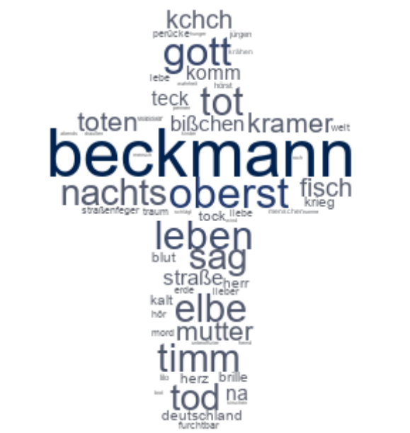

```r
bild = "data/Antconc/Antconc_wordcloud_borchert_prozess_nach_likelihood.png"
knitr::include_graphics(bild)
```

## 12 Regex in Antconc

**Einführung:**

In dieser Übung lernen Sie, reguläre Ausdrücke (*Regular Expressions*, kurz *Regex*) in **AntConc** anzuwenden, um gezielt bestimmte Wortformen in einem Korpus zu finden.  
Ziel ist es, alle Wortformen zu extrahieren, die das lexikalische Morphem **“uhr”** enthalten. Dabei sollen nur solche Formen berücksichtigt werden, bei denen “uhr” eigenständig als Bestandteil vorkommt, zum Beispiel in Komposita wie *Telleruhr* oder *Küchenuhr*.  
Formen wie *fuhr* oder *erfuhr* — bei denen “uhr” Teil eines anderen lexikalischen Morphems ist — sollen ausgeschlossen werden.

**Lösungsidee:**

In regulären Ausdrücken müssen wir ein Suchmuster definieren, das:

1. **“uhr”** als Ganzes enthält,
2. **direkt an ein anderes Morphem angeschlossen** sein kann (z.B. “Küchenuhr”),
3. **keine Formen trifft**, in denen “uhr” nicht eigenständig ist.

Da Wörter wie *fuhr* oder *erfuhr* kein eigenständiges “uhr” enthalten, sondern die Zeichenfolge “uhr” Teil eines anderen Morphems ist, hilft eine *Wortgrenze* (`\b`) an der richtigen Stelle.

**Konkret für AntConc:**

In AntConc verwenden wir reguläre Ausdrücke im “Word List” oder “Concordance” Tool. Dort kann das Regex-Feld aktiviert werden.

Ein mögliches Suchmuster lautet:

```
\w+uhr\w*
```

**Erklärung:** - `\w+` — ein oder mehrere Wortzeichen (also Buchstaben, Zahlen oder Unterstriche) **vor** “uhr”, - `uhr` — die zu findende Zeichenkette, - `\w*` — null oder mehr Wortzeichen **nach** “uhr”.

Dieses Muster findet Wörter wie: - **Küchenuhr** - **Armbanduhr** - **Telleruhr** - **Wanduhr**

aber auch *fuhr*, *erfuhr* usw., weil diese ja ebenfalls “uhr” enthalten.

**Wie können wir *fuhr* und *erfuhr* ausschließen?**

Wir brauchen ein genaueres Muster. Eine Möglichkeit ist, dass wir *nur solche Wörter suchen, bei denen “uhr” am Anfang eines neuen Morphems steht* – und das beginnt typischerweise mit einem Großbuchstaben oder Bindestrich in Komposita.

Das geht in AntConc allerdings *ohne komplexe linguistische Annotation* nur näherungsweise. Eine einfache Strategie ist:

- **Nur Treffer erlauben, bei denen “uhr” nicht direkt nach “f” oder “e” kommt**, um *fuhr*, *erfuhr* auszuschließen.

Das ginge etwa so:

```
\b\w*[^fe]uhr\w*\b
```

**Erklärung:** - `\b` — Wortgrenze (Anfang), - `\w*` — beliebige Buchstaben, - `[^fe]` — ein Zeichen, das **nicht** “f” oder “e” ist, - `uhr` — das Zielmorphem, - `\w*` — beliebige weitere Buchstaben, - `\b` — Wortgrenze (Ende).

**Aber:** Das schließt nur “f” und “e” direkt vor “uhr” aus.  
Falls in eurem Korpus auch *verfuhr*, *aufgefuhr* usw. vorkommen sollten, wäre das nicht ausreichend. Eine saubere Lösung müsste also ggf. linguistisch über Stemming/Lemmatisierung erfolgen — oder mit einer noch genaueren Regex.

**Zusammenfassung für die Studierenden:**

- Starten Sie mit dem Muster: `\w+uhr\w*`
- Prüfen Sie, welche unerwünschten Wörter (z.B. *fuhr*) auftreten.
- Verfeinern Sie das Muster: `\b\w*[^fe]uhr\w*\b`
- Diskutieren Sie die Grenzen von Regex-Suchen ohne linguistische Annotation.

### 12.1 Vergleichstabelle: Anwendung von regulären Ausdrücken (Regex) für das Morphem “uhr” in AntConc, R und Python

| Tool | Regex-Ausdruck | Bemerkung |
| --- | --- | --- |
| **AntConc** | `\w+uhr\w*` | Findet Wörter, die “uhr” enthalten; auch unerwünschte Formen wie *fuhr* werden getroffen. |
| **AntConc** | `\b\w*[^fe]uhr\w*\b` | Schließt einfache unerwünschte Präfixe wie *f* oder *e* aus; begrenzte Präzision. |
| **R** (stringr) | `str_subset(wörter, "\\b\\w*[^fe]uhr\\w*\\b")` | Sucht in einem Vektor `wörter`; `\\b` für Wortgrenze, doppelt maskiert in R-Strings. |
| **Python** (re) | `[re.search(r"\b\w*[^fe]uhr\w*\b", wort) for wort in wörter]` | Nutzt `re.search` zur Suche innerhalb eines Listenobjekts `wörter`. |

### 12.2 Weiterführung der Aufgabe

#### 12.2.1 1. *Zusätzlich* “Uhr” als Einzelwort und in flektierten Formen finden

- Ziel: Auch Formen wie **Uhr**, **Uhren**, **Uhrensammlung** sollen gefunden werden.
- Regex kann erweitert werden:

| Tool | Regex-Ausdruck | Bemerkung |
| --- | --- | --- |
| **AntConc** | `\bUhr\w*\b` | Findet “Uhr”, “Uhren”, “Uhrensammlung” etc., aber nicht zusammengesetzte Erstglieder. |
| **R** (stringr) | `str_subset(wörter, "\\bUhr\\w*\\b")` | Sucht Wörter, die mit “Uhr” beginnen. |
| **Python** (re) | `[re.search(r"\bUhr\w*\b", wort) for wort in wörter]` | Dasselbe Vorgehen wie oben. |

**Hinweis:** Wenn auch Kleinschreibung berücksichtigt werden soll (z.B. “uhr”), kann die Suche *case-insensitive* durchgeführt werden: - **AntConc**: Option “Case Insensitive” aktivieren. - **R**: `str_subset(wörter, regex("\\bUhr\\w*\\b", ignore_case = TRUE))` - **Python**: `re.search(r"\bUhr\w*\b", wort, flags=re.IGNORECASE)`

#### 12.2.2 2. Nur *Zusammensetzungen* finden, keine isolierte “Uhr”

- Ziel: Treffer wie *Armbanduhr*, *Küchenuhr*, **aber nicht** “Uhr” allein oder “Uhren”.
- Ansatz: Regex so gestalten, dass *mindestens ein Präfix* vorhanden ist.

| Tool | Regex-Ausdruck | Bemerkung |
| --- | --- | --- |
| **AntConc** | `\b\w+uhr\w*\b` | `\w+` zwingt mindestens ein Zeichen vor “uhr”. |
| **R** | `str_subset(wörter, "\\b\\w+uhr\\w*\\b")` |  |
| **Python** | `[re.search(r"\b\w+uhr\w*\b", wort) for wort in wörter]` |  |

(also wie ursprünglich vorgeschlagen)

#### 12.2.3 3. Wortformen nach Typen aufteilen: Einzelwörter vs. Komposita

- Aufgabe: Programmieren Sie eine einfache Klassifikation:
  - Wenn ein Wort **nur “Uhr”** oder **“Uhren”** enthält → Typ = “Einzelwort”.
  - Wenn ein Wort eine zusammengesetzte Form enthält (z.B. *Armbanduhr*) → Typ = “Kompositum”.

In **R** könnte dies z.B. so aussehen:

```r
library(stringr)
dplyr::tibble(wort = wörter) %>%
  dplyr::mutate(typ = dplyr::case_when(
    str_detect(wort, "^Uhr(en)?$") ~ "Einzelwort",
    str_detect(wort, "uhr") ~ "Kompositum",
    TRUE ~ "kein Treffer"
  ))
```

In **Python**:

```python
import re
def klassifizieren(wort):
    if re.fullmatch(r"Uhr(en)?", wort, flags=re.IGNORECASE):
        return "Einzelwort"
    elif re.search(r"uhr", wort, flags=re.IGNORECASE):
        return "Kompositum"
    else:
        return "kein Treffer"

klassifizierungen = [klassifizieren(w) for w in wörter]
```

### 12.3 Fazit

✅ Die Übung fördert bei Studierenden: - das Verständnis von Morphemen und lexikalischer Struktur, - den praktischen Umgang mit regulären Ausdrücken in verschiedenen Tools, - die Transferfähigkeit zwischen Benutzeroberflächen (AntConc) und Programmiersprachen (R, Python), - die Problembewusstheit bezüglich Unsicherheiten von Regex-Suchen (z.B. Stemming-Problematik).

Sehr gerne. Hier ist eine **formal strukturierte Lösungsschablone**, die Sie direkt für Ihre Lehre verwenden können.  
Ich halte sie wissenschaftlich und klar formuliert, angepasst an eine Übungs- oder Aufgabenstellung.

### 12.4 Lösungsschablone: Suchen und Filtern von Wortformen mit regulären Ausdrücken

#### 12.4.1 Ziel

Finden Sie alle Wörter, die das lexikalische Morphem **“uhr”** enthalten,  
**einschließlich**: Einzelwörter (*Uhr, Uhren*) und Komposita (*Telleruhr, Küchenuhr*),  
**aber ausschließend**: Wortformen wie *fuhr*, *erfuhr*, *verfuhr*.

#### 12.4.2 Arbeitsschritte

##### 12.4.2.1 1. Positivsuche: Alle Wortformen mit “uhr” erfassen

**Regex-Ausdruck:**

```
\bUhr\b|\w+uhr\w*
```

**Anwendung:** - In **R**: `str_subset()` mit `regex(..., ignore_case = TRUE)` - In **Python**: `re.search()` mit `re.IGNORECASE`

##### 12.4.2.2 2. Negativfilterung: Unerwünschte Treffer ausschließen

**Regex-Ausdruck für auszuschließende Formen:**

```
^(fuhr|erfuhr|verfuhr)$
```

- Schließt gezielt vollständige Wortformen wie *fuhr*, *erfuhr*, *verfuhr* aus.
- `^` Anfang des Wortes, `$` Ende des Wortes → ganze Wortform wird überprüft.

**Anwendung:** - In **R**: `!str_detect()` mit `regex(..., ignore_case = TRUE)` - In **Python**: `not re.fullmatch(..., flags=re.IGNORECASE)`

##### 12.4.2.3 3. Zusammenführen: Endgültige Trefferliste erstellen

**Logik:** - (Positiv-Treffer) UND (Nicht in Negativliste).

##### 12.4.2.4 R-Beispiel

```r
library(stringr)

wörter <- c("fuhr", "erfuhr", "verfuhr", "Küchenuhr", "Telleruhr", "Uhren", "Uhr", "Uhrzeit", "AutoUhr")

# Schritt 1: Suchen
treffer <- str_subset(wörter, regex("\\buhr\\b|\\w+uhr\\w*", ignore_case = TRUE))

# Schritt 2: Filtern
endgültige_treffer <- treffer[!str_detect(treffer, regex("^(fuhr|erfuhr|verfuhr)$", ignore_case = TRUE))]

endgültige_treffer
```

##### 12.4.2.5 Python-Beispiel

```python
import re

wörter = ["fuhr", "erfuhr", "verfuhr", "Küchenuhr", "Telleruhr", "Uhren", "Uhr", "Uhrzeit", "AutoUhr"]

# Schritt 1: Suchen
treffer = [w for w in wörter if re.search(r"\buhr\b|\w+uhr\w*", w, flags=re.IGNORECASE)]

# Schritt 2: Filtern
endgültige_treffer = [w for w in treffer if not re.fullmatch(r"(fuhr|erfuhr|verfuhr)", w, flags=re.IGNORECASE)]

print(endgültige_treffer)
```

#### 12.4.3 Zusammenfassung des Vorgehens

| Schritt | Beschreibung | Werkzeug |
| --- | --- | --- |
| 1 | Positivsuche: alle Wörter mit “uhr” erfassen | Regex-Suche (`str_subset`, `re.search`) |
| 2 | Negativfilterung: Ausschluss von *fuhr*, *erfuhr*, *verfuhr* | Regex-Filter (`str_detect`, `re.fullmatch`) |
| 3 | Ergebnislisten erstellen und überprüfen | Ausgabe, ggf. weitere Bearbeitung |

#### 12.4.4 Erweiterungsmöglichkeiten für die Studierenden

- Hinzufügen weiterer Ausnahmen (z.B. *veruhr*, falls es im Korpus auftritt).
- Automatische Erkennung weiterer unerwünschter Präfixe mit Listen.
- Anwendung auf große Korpora mit mehreren Tausend Wörtern.
- Visualisierung der Trefferhäufigkeit (z.B. Histogramme in R/Python).